# count_domains_v1

## Counting domains in proteins from SGD, v1

On 2/21/2018 I downloaded proteins containing at least 1 identified domain, in a csv file with human-readable headers.

This script counts the number of identified domains in each protein (grouped by systematic name, e.g. YLR190W).

To start, we load some code packages into R, and give the folder location of the data files we want to use:

```r
library(dplyr)
library(readr)
library(ggplot2)
library(knitr)

# datapath <- "/Users/theresa/Documents/home-github/data-analysis/R/count_domains_data"
datapath <- "/Users/confocal/github_theresaswayne/data-analysis/R/count_domains_data"
datafile <- "20180221_SGDproteins_atleast1domain.csv"
```

## The original file

We read the CSV file from SGD and convert it into an R “object,” and R tells us the columns it found:

```r
# unlike base R's read.csv, readr's read_csv gives a tbl that can be grouped
proteins <- read_csv(file.path(datapath, datafile))
```

We can confirm it has 45780 rows and 8 columns:

```r
dim(proteins)
```

```
## [1] 45780     8
```

And we can look at the top of the file:

```r
kable(proteins[1:20,], caption = "Original protein data")
```

Original protein data

| Gene > Proteins > Systematic Name | Gene > Proteins > Standard Name | Gene > Proteins > Protein Domains > Name | Gene > Proteins > Protein Domains > Description | Gene > Proteins > Protein Domains > Start | Gene > Proteins > Protein Domains > End | Gene > Proteins > Protein Domains > Method | Gene > Proteins > Protein Domains > Id |
| --- | --- | --- | --- | --- | --- | --- | --- |
| Q0045 | Cox1p | G3DSA:1.20.210.10 | Cytochrome c oxidase-like, subunit I domain | 1 | 534 | GENE3D | 1939335 |
| Q0045 | Cox1p | PF00115 | COX1; Cytochrome c oxidase subunit I | 13 | 460 | Pfam | 1939336 |
| Q0045 | Cox1p | PR01165 | CYCOXIDASEI; Cytochrome c oxidase subunit I | 4 | 29 | PRINTS | 1939337 |
| Q0045 | Cox1p | PR01165 | CYCOXIDASEI; Cytochrome c oxidase subunit I | 53 | 76 | PRINTS | 1939338 |
| Q0045 | Cox1p | PR01165 | CYCOXIDASEI; Cytochrome c oxidase subunit I | 81 | 105 | PRINTS | 1939339 |
| Q0045 | Cox1p | PR01165 | CYCOXIDASEI; Cytochrome c oxidase subunit I | 123 | 135 | PRINTS | 1939340 |
| Q0045 | Cox1p | PR01165 | CYCOXIDASEI; Cytochrome c oxidase subunit I | 155 | 173 | PRINTS | 1939341 |
| Q0045 | Cox1p | PR01165 | CYCOXIDASEI; Cytochrome c oxidase subunit I | 184 | 203 | PRINTS | 1939342 |
| Q0045 | Cox1p | PR01165 | CYCOXIDASEI; Cytochrome c oxidase subunit I | 235 | 256 | PRINTS | 1939343 |
| Q0045 | Cox1p | PR01165 | CYCOXIDASEI; Cytochrome c oxidase subunit I | 281 | 296 | PRINTS | 1939344 |
| Q0045 | Cox1p | PR01165 | CYCOXIDASEI; Cytochrome c oxidase subunit I | 305 | 326 | PRINTS | 1939345 |
| Q0045 | Cox1p | PR01165 | CYCOXIDASEI; Cytochrome c oxidase subunit I | 340 | 358 | PRINTS | 1939346 |
| Q0045 | Cox1p | PR01165 | CYCOXIDASEI; Cytochrome c oxidase subunit I | 368 | 387 | PRINTS | 1939347 |
| Q0045 | Cox1p | PR01165 | CYCOXIDASEI; Cytochrome c oxidase subunit I | 418 | 439 | PRINTS | 1939348 |
| Q0045 | Cox1p | PS00077 | COX1_CUB; Cytochrome c oxidase, subunit I, copper-binding site | 237 | 291 | PROSITE | 1939349 |
| Q0045 | Cox1p | PS50855 | COX1; Cytochrome c oxidase-like, subunit I domain | 1 | 534 | PROSITE | 1939350 |
| Q0045 | Cox1p | PTHR10422 | Cytochrome c oxidase subunit I | 1 | 528 | PANTHER | 1939351 |
| Q0045 | Cox1p | PTHR10422:SF30 | NA | 1 | 528 | PANTHER | 1939352 |
| Q0045 | Cox1p | SSF81442 | Cytochrome c oxidase-like, subunit I domain | 3 | 529 | SUPERFAMILY | 1939353 |
| Q0050 | Ai1p | G3DSA:1.20.210.10 | Cytochrome c oxidase-like, subunit I domain | 1 | 104 | GENE3D | 1940022 |

Now we can use the “group_by” function to collate all the rows that share the same systematic name.

```r
proteins_by_protname <- group_by(proteins, proteins$`Gene > Proteins > Systematic Name`)
```

To see the effect of this, we run the “summarize” function and sort the table in decreasing order of number of rows.

```r
# Count rows bearing each protein name  --------
domains_per_protein <- summarize(proteins_by_protname, n())

# Sort by # domains.
# Use backticks around the column name because it has parentheses
inorder <- arrange(domains_per_protein, desc(`n()`))
```

Now we have a table showing 5418 unique proteins and the number of detected domains in each:

```r
dim(inorder)
```

[1] 5418 2

```r
kable(inorder[1:10,], caption = "Proteins sorted by # domains")
```

Proteins sorted by # domains

| proteins$`Gene > Proteins > Systematic Name` | n() |
| --- | --- |
| YJL130C | 70 |
| YJL005W | 69 |
| YMR229C | 61 |
| YCR072C | 44 |
| YLR129W | 44 |
| YLR222C | 44 |
| YPR186C | 44 |
| YBR198C | 42 |
| YCR057C | 42 |
| YNL088W | 42 |

## Frequency distribution of domains per protein

We can plot how many domains are observed per protein:

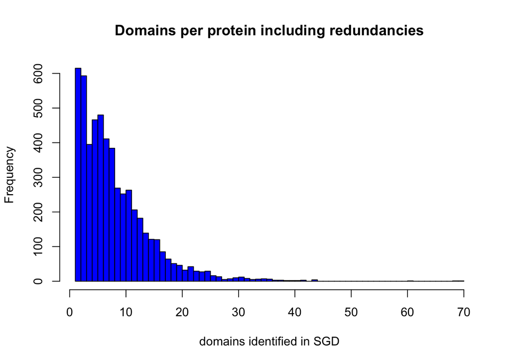

Finally, we can save a PDF of the plot, and the data table listing number of domains per protein:

```r
# Create and save histogram of domains per protein ---------------------------------

outputgraph <- file.path(datapath,"domains_per_prot_redundant.pdf")
pdf(file = outputgraph)

hist(domains_per_protein$`n()`, breaks = 70, col = "blue", main="Domains per protein including redundancies", xlab="domains identified in SGD")

invisible(dev.off()) # closes pdf output


# Save data table -----------------------------------------------

outputfile <- "proteins_by_number_domains.csv"
write.csv(inorder, file.path(datapath,outputfile))
```

Future plans:

```r
# Next steps:
# -- eliminate redundant domains using start and end residues
# -- filter by domains that are involved in protein-protein interactions

# Refinements:
# -- prompt user for file
# -- check for required columns
# -- rename columns in summary to something sensible
# -- format histogram nicely
```